# Análisis de la distribución de las instituciones de educación especial en el Perú durante el año 2015

##### **Cálculo del intervalo de confianza para la media de alumnos por sección en el Perú**

```r
cn(0.9, sd(al_Sec), 0.35)
```

```
## [1] 244.5136
```

```r
Muestra.al.sec <- sample(al_Sec, 245, replace = FALSE)
Muestra.al.sec
```

```
##   [1]  2.000000  2.428571  1.888889  3.700000  1.666667  3.142857  1.666667
##   [8]  1.400000  2.625000  3.272727  3.571429 11.277778  2.750000  7.312500
##  [15]  4.545455  8.333333  2.333333  2.000000  3.538462  5.571429  8.300000
##  [22]  2.000000  5.818182 10.666667  3.000000  8.500000  2.500000  3.250000
##  [29] 12.000000  2.333333  3.125000  3.666667 11.250000  4.285714  2.500000
##  [36]  1.000000  3.428571  7.000000 11.750000 10.000000  5.375000  1.000000
##  [43]  8.700000  9.000000  8.777778  2.333333  3.916667  8.000000  4.222222
##  [50]  2.900000  3.142857  8.428571  3.750000  2.875000  1.750000  3.200000
##  [57]  1.750000  1.750000  4.000000  2.285714  9.000000  4.700000  2.833333
##  [64]  3.333333  7.800000  7.666667  5.428571  2.500000  4.222222  1.285714
##  [71]  8.400000  6.727273  1.500000  2.000000  8.846154  6.071429  4.000000
##  [78]  2.000000  4.000000  3.200000 14.625000  7.500000  2.111111  2.333333
##  [85]  5.875000  3.636364  1.714286  2.600000  4.666667  1.428571  1.888889
##  [92]  3.333333 11.333333  3.666667  3.333333  1.500000  2.777778  2.000000
##  [99]  4.000000  2.625000 28.200000  1.000000 10.545455  1.833333  6.428571
```

[output cut: 20 more lines]

```
## [1] 4.310257 5.009562
```

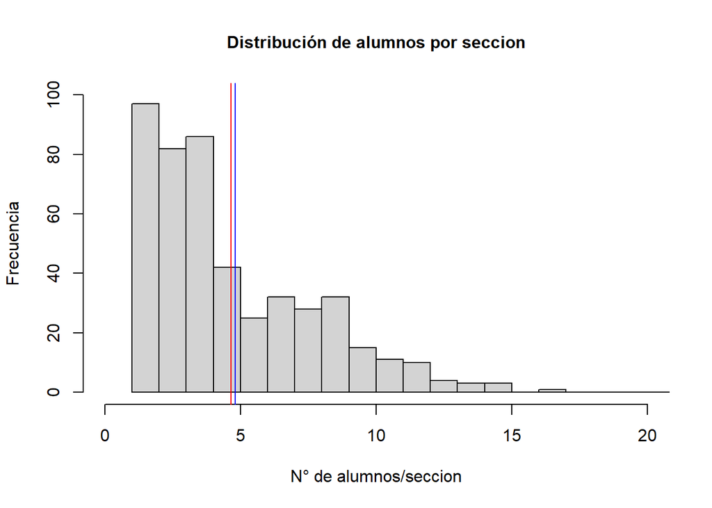

Compararemos lo que nos dice la prueba de hipótesis con la respuesta obtenida directamente de la población. En esta ocasión se propone lo siguiente:

```r
mean(al_Sec)
```

```
## [1] 4.816287
```

Ya que se conoce la media de la población, veremos si la prueba de hipótesis coordina con este resultado:

```r
hipvarcon(media.mues=mean(Muestra.al.sec), mu=2, varia=var(al_Sec), signifi=0.05, n=245, alt="derecha")
```

```
## [1] "La H0 no cumple, se rechaza"
```

Como podemos observar, la H0 no se cumple. Esto quiere decir que la media de alumnos por sección debería ser mayor a 2, lo que en definitiva es cierto.